# Discussion-12

waheeb Algabri

# Assignment

Using R, build a multiple regression model for data that interests you. Include in this model at least one quadratic term, one dichotomous term, and one dichotomous vs. quantitative interaction term. Interpret all coefficients. Conduct residual analysis. Was the linear model appropriate? Why or why not?

# Preliminaries

If you haven’t already done so, then install the [tidyverse][1] collection of packages, and the [jtools][2] package. Functions from the jtools package depend on at least two other packages, ggstance, and huxtable, so you will also need to install those packages. You should also install the corrplot package if you have not already done so.

You only need to install these packages once on the machine that you’re using. If you have not already done so, then you can do so by uncommenting the code chunk below and running it. If you *have* already done so, then you should *not* run the next code chunk.

```r
# install.packages('tidyverse')
# install.packages('jtools')
# install.packages('ggstance')
# install.packages('huxtable')
# install.packages('corrplot')
```

Load the tidyverse collection of packages.

```r
library(tidyverse)
library(jtools) # For tabulating and visualizing results from multiple regression models
library(corrplot)
```

Data

https://www.kaggle.com/datasets/mirichoi0218/insurance

```r
df <- read_csv('https://raw.githubusercontent.com/waheeb123/Datasets/main/insurance.csv')
head(df)
```

```
## # A tibble: 6 × 7
##     age sex      bmi children smoker region    charges
##   <dbl> <chr>  <dbl>    <dbl> <chr>  <chr>       <dbl>
## 1    19 female  27.9        0 yes    southwest  16885.
## 2    18 male    33.8        1 no     southeast   1726.
## 3    28 male    33          3 no     southeast   4449.
## 4    33 male    22.7        0 no     northwest  21984.
## 5    32 male    28.9        0 no     northwest   3867.
## 6    31 female  25.7        0 no     southeast   3757.
```

```r
sum(is.na(df))
```

```
## [1] 0
```

# Simple Regressions

Creating a linear model using more than one explanatory variable is easy to do in R, but we also want to illustrate that it’s not simply a combination of coefficients from many simple regressions that include only one predictor variable. (By the way, a simple regression is a regression in which there is only one predictor variable.)

As a benchmark, let’s first calculate simple regression models of charges on age and bmi and store the coefficients and then aggregate R-squared values in dataframes for comparison purposes.

```r
lm1 <- lm(charges ~ age, data = df)
lm2 <- lm(charges ~ bmi, data = df)
export_summs(lm1, lm2) # Create a nice looking table for comparing the regression results
```

|  | Model 1 | Model 2 |
| --- | --- | --- |
| (Intercept) | 3165.89 *** | 1192.94 |
|  | (937.15) | (1664.80) |
| age | 257.72 *** |  |
|  | (22.50) |  |
| bmi |  | 393.87 *** |
|  |  | (53.25) |
| N | 1338 | 1338 |
| R2 | 0.09 | 0.04 |
| *** p < 0.001; ** p < 0.01; * p < 0.05. |  |  |

Model 1, using age as a predictor, has a higher R-squared value (0.09) and indicates that for each year increase in age, charges increase by $257.72. Model 2, using BMI as a predictor, has a lower R-squared value (0.04) but suggests that for each unit increase in BMI, charges increase by $393.87. Both models are statistically significant (p < 0.001).

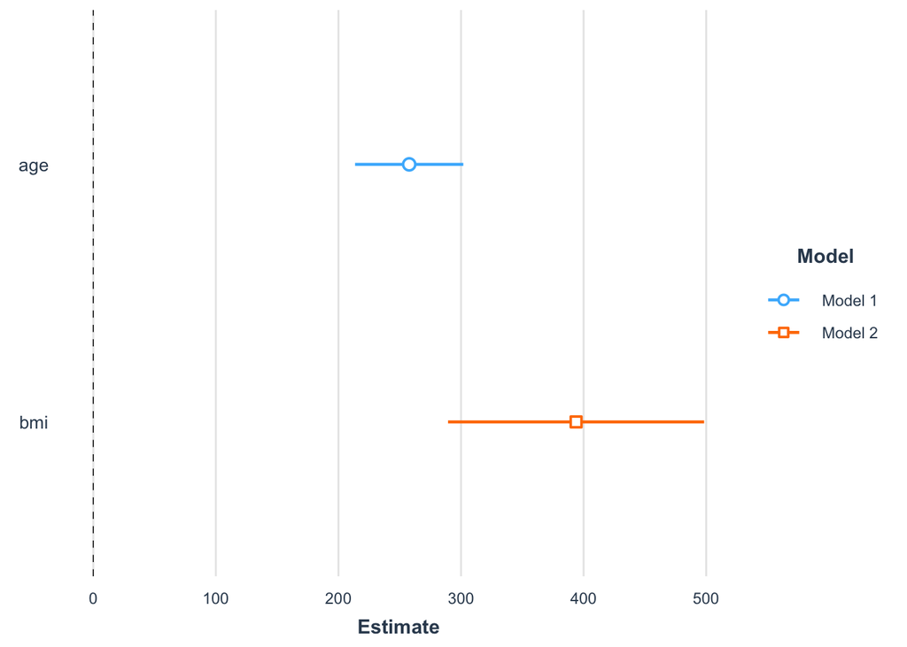

```r
plot_summs(lm1, lm2)
```

# Multiple Regression of Charges on age and bmi

Now, let’s run a multiple regression that contains both predictor variables in the same model, and evaluate the models. It’s called a multiple regression because it has multiple predictor variables.

```r
lm3 <- lm(charges ~ age + bmi, data = df)
export_summs(lm1, lm2, lm3)
```

|  | Model 1 | Model 2 | Model 3 |
| --- | --- | --- | --- |
| (Intercept) | 3165.89 *** | 1192.94 | -6424.80 *** |
|  | (937.15) | (1664.80) | (1744.09) |
| age | 257.72 *** |  | 241.93 *** |
|  | (22.50) |  | (22.30) |
| bmi |  | 393.87 *** | 332.97 *** |
|  |  | (53.25) | (51.37) |
| N | 1338 | 1338 | 1338 |
| R2 | 0.09 | 0.04 | 0.12 |
| *** p < 0.001; ** p < 0.01; * p < 0.05. |  |  |  |

Model 3, incorporating both age and BMI as predictors, has the highest R-squared value (0.12), suggesting it explains the most variance in charges. The coefficients in Model 3 indicate that for each year increase in age, charges increase by $241.93, and for each unit increase in BMI, charges increase by $332.97. All models are statistically significant (p < 0.001). This summary provides an overview of the three models and their respective predictors in explaining the variation in charges.

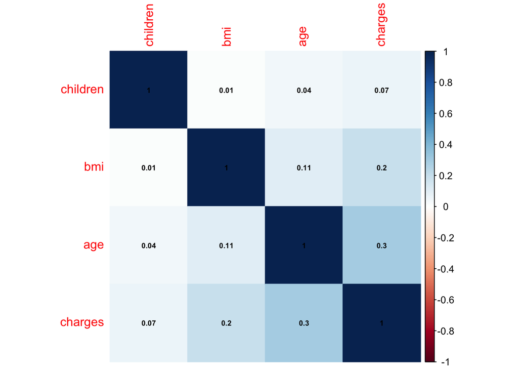

```r
ctrd <- cor(df[, sapply(df, is.numeric)])
corrplot(ctrd
         , method = 'color' # I also like pie and ellipse
         , order = 'hclust' # Orders the variables so that ones that behave similarly are placed next to each other
         , addCoef.col = 'black'
         , number.cex = .6 # Lower values decrease the size of the numbers in the cells
         )
```

This change is effectively communicated by visualizing the coefficients from all three models.

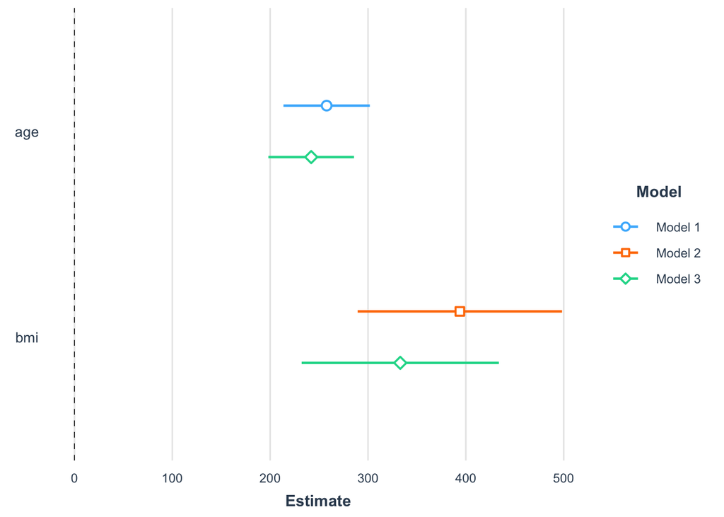

```r
plot_summs(lm1, lm2, lm3)
```

```r
# Adding quadratic term for age
df$age_squared <- df$age^2

# Adding a dichotomous term for smoker (0: non-smoker, 1: smoker)
df$smoker_binary <- as.integer(df$smoker == "yes")

# Building the multiple regression model with quadratic term, dichotomous term, and interaction term
lm4 <- lm(charges ~ age + age_squared + bmi + smoker_binary + age:bmi, data = df)
summary(lm4)
```

```
##
## Call:
## lm(formula = charges ~ age + age_squared + bmi + smoker_binary +
##     age:bmi, data = df)
##
## Residuals:
##      Min       1Q   Median       3Q      Max
## -11943.2  -3004.9   -937.5   1417.0  29398.2
##
## Coefficients:
##                 Estimate Std. Error t value Pr(>|t|)
## (Intercept)   -8244.8672  2727.8205  -3.023  0.00255 **
## age              58.8671    94.2674   0.624  0.53243
## age_squared       2.6010     0.9766   2.663  0.00783 **
## bmi             326.7324    79.8794   4.090 4.57e-05 ***
## smoker_binary 23833.1780   412.2011  57.819  < 2e-16 ***
## age:bmi          -0.1678     1.9522  -0.086  0.93151
## ---
## Signif. codes:  0 '***' 0.001 '**' 0.01 '*' 0.05 '.' 0.1 ' ' 1
##
## Residual standard error: 6081 on 1332 degrees of freedom
## Multiple R-squared:  0.7488, Adjusted R-squared:  0.7479
## F-statistic: 794.2 on 5 and 1332 DF,  p-value: < 2.2e-16
```

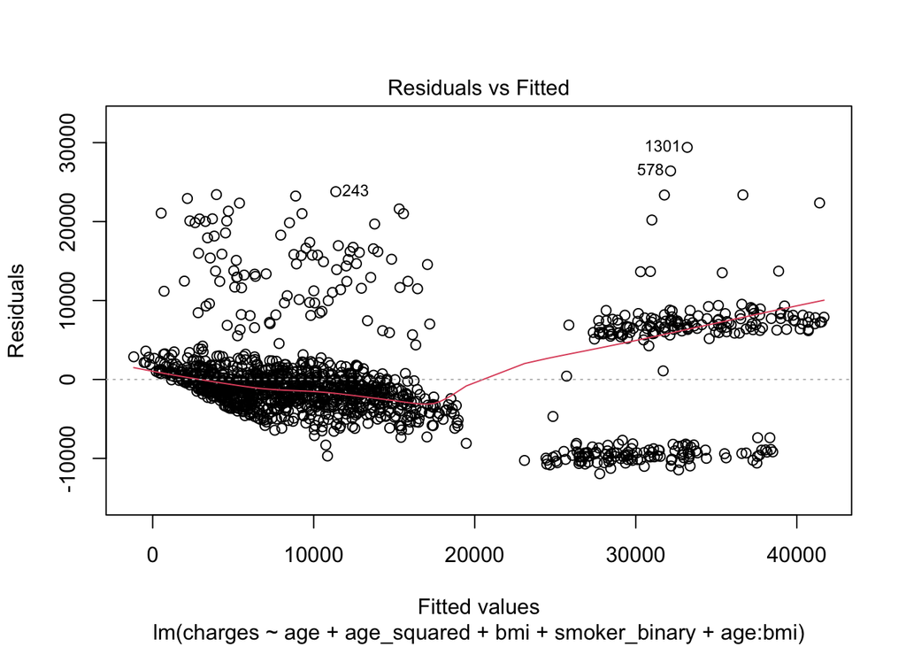

```r
# Residual analysis
plot(lm4, which = 1)  # Residuals vs Fitted
```